# Basic Statistics in R

Sandra Erdmann

```r
library(ggplot2)
```

# Basic Statistics in R

http://www.flutterbys.com.au/stats/

## Basics

### Markdown

To create a **Markdown** file, choose ‘R Markdown" clicking on the plus symbol below the ’File’ tab.

Markdown trick: This addition in your chunk title will avoid to rerun the model in the Markdown file!!! Do not do that for your libraries though!

```
{r mckeonModel, cache=TRUE}
```

### Short cuts

```
Control+Alt+i : insert new chunk
Control+Shift+Enter : run current chunk
Control+Shift+m : %>%
```

### Equations

http://www.math.mcgill.ca/yyang/regression/RMarkdown/example.html

To include equations into a text use only one dollar sign. If you wish to display the equation in a seperate line, then use two dollar signs.

Here are some examples:

```
$$ \mu = 5 $$
```

$$\mu = 5$$
Use this to make a fraction

```
$$ \frac{4z^3}{16}
```

$$\frac{4z^3}{\sqrt16}$$
These are some special characters, such as bigger or smaller as:

```
$$a \pm b$$
```

$$a \pm b$$

```
$$x \ge 15$$
```

$$x \ge 15$$

```
$$a_i \ge 0~~~\forall i$$
```

$$a_i \ge 0~~~\forall i$$
To put big brackets use right and left commands

```
$$\sum_{i=1}^{n}\left( \frac{X_i}{Y_i} \right)$$
```

$$\sum_{i=1}^{n}\left( \frac{X_i}{Y_i} \right)$$
To display Greek letters, use the backslash before the greek word

```
$$\alpha, \beta,  \gamma, \Gamma$$
```

$$\alpha, \beta, \gamma, \Gamma$$
This is the sum symbol:

```
$$ X = \sum_{i=1}^n X_i / n  $$
```

$$X = \sum_{i=1}^n X_i$$

To use X bar, you will need to define it first within the equation:

```
\Xbar = \sum_{i=1}^n\frac {x_i}{n}  = \frac{x_1 + x_2 + ... + x_n}{n}$$
```

### General

Choose the first column by typing

```
[,1]
```

### Load datasets

To load a dataset, you type :

```
dataset<- read.csv('C:/Users/admin/Desktop/R-Course by Murray/07092018/dataset.csv', strip.white=T)
```

strip.white=T means, that you exclude all spaces in your excel file to avoid complications.

For import, simply run the chunk, which contains your dataset.

### Github

Is a platform to store your latest R Studio versions and if you wish to work on R projects with others.

Follow these instructions: http://r-pkgs.had.co.nz/git.html

Install Git first with this link: http://git-scm.com/download/win.

Click on Tools and choose global options. Click on Git/SVN and click on ‘Create RSA key’. Add the key to https://github.com/settings/ssh.

Now create a new repository. Click on Tools and then project options, Click on Git/SVN and chose version control GIT

You can create new repositories, create new branches, make and commit branches,

## Statistical terms

https://select-statistics.co.uk/resources/glossary-page/

http://www.ecologyandevolution.org/statsdocs/glossary.pdf

**alpha** : Type I error

**asymptotic** :

**beta** : Type II error **beta** : regression coefficient

**CV** : the coefficient of variation represents how data are spread relative to the mean of the population (mu) or sample (Xbar). SD is the standard deviation of a population (sigma) or a sample (s). It is used to compare the spread of data (quantitative) with the same units (in %) or to compare the variables between two groups with different units (unitless)!

$$CV = \frac{SD}{mean}$$

**categorical variable vs. numeric** : a variable that is a category, such as yellow, blue, brown or high and low, etc. is a categorical as well as a qualitative variable, whereas numerics can take decimal or fractional values. They are considered quantative, such as intervals or ratios.

**Chi-Square** :

**confidence intervals** : provides a confidence range that the true value lies in this range.

**continuous vs. discrete** : a value that is measured numerically and can have a wide and infinite range of values (1, 2, …) is continuous, whereas a discrete number has eiter one or the other outcome of a random variable, for example, head or tails.

**degrees of freedom** :

**dependent vs. independent variable** : the dependent variable y (DV) is also called the response variable. Loosely speaking, it “depends on” the independent variable. the independent x variable (IV), also called the predictor, is not depending on th dependent variable.

**hat matrix** :

**homogeneity of variance** : if the variance of … is equal across … variables

**integer** : integers cannot take decimal or fractional values, while numerics can.

**Maximum Likelihood** : gets used in generalized linear models

**multicollinearity** : When there are linear relationships (correlations) between two or more of the potential drivers; this can lead to difficulty in the interpretation of the model coefficients. Example: a questionnaire might ask whether the staff were friendly, and also whether they were helpful, which we would expect to be highly related. There are various statistical approaches that can be used to deal with multicollienarity, including the use of principal component analysis PCA to reduce the number of potential drivers to a set of linearly uncorrelated variables.

**multiple regression** : a type of regression analysis that includes several independent variables.

**NMDS** : non multidimensional scale

**non-parametric test** : a statistical test that does not assume that the data follow a particular probability distribution.

**offset** : is to standardize what?

**OLS** : Ordinary Least Squares; concept gets used in linear models

**overdispersed** :

**overfitted** : in linear regression models, when the datapoints are spread like a curve, but the fitted regression line results as a vertical line, since the residuals sum up as 0.

**overinflated** :

**PCA** : principal component analysis

**r** : Pearson’s correlation coefficient

**R Square** : A statistical parameter in regression analysis that measures the amount of variation in the dependent variable that is explained by variation in the independent variable. In a scatterplot, the higher the R2, the more tightly the data will be clustered around the regression line. If all values fall on the line, R2=1. The value of R2 can vary from 0 to 1.

**standard error versus standard deviation** : it is important to distinguish between the standard deviation of the data, which is a measure of variability or dispersion computed from the probability distribution function and the standard error, which provides you with certainty about the population mean as estimated from a specific sample.

**SRS** : simple random sampling

**univariate vs bivariate vs. multivariate** : univariate describe characteristics of one variable (e.g. mean and bar chart or histogram), bivariate describe characteristics of two variables (e.g. Pearson’s correlation coefficient and scatterplot) and multivariate describe characteristics of many variable (e.g. multiple correlation and multivariate regression)

## Statistical Introduction

### Population

A **population** is our subject of observation. Its mean mu is characterized by the following equation:

$$\mu = \sum_{i=1}^N\frac {x_i}{N} = \frac{x_1 + x_2 + ... + x_N}{N}$$

where

$x_i$ is the sum of the datapoints

$i=1$ from the first datapoint

$N$ to all datapoints

The **variance** sigma square is the population variance, which describes the variance or distance from the mean. The following formula is used to describe a population:

$$\sigma^2 = \sum_{i=1}^N\frac {(x_i-\mu)^2}{N}$$

The bigger the resulting value, the further away your datapoints are from the mean. The reason why we square within the formula is, because we aim to get a positive resulting value.

For the **standard deviation** (SD) of a population, use the square root of the variance:

$$\sigma = \sqrt {\sigma^2}$$

### Sample

A **sample** is a measurement taken from a population in order to infer about the population.

The sample mean is called X bar with the according following formula:

$$\def\Xbar{\overline{X}}
\Xbar = \sum_{i=1}^n\frac {x_i}{n} = \frac{x_1 + x_2 + ... + x_n}{n}$$

where n is the number of measurements taken.

The sample **variance** is called s square and is based on this formula:

$$\def\Xbar{\overline{X}}
s^2 = \sum_{i=1}^n\frac {(x_i-\Xbar)^2}{n}$$
Alternatively use this formula:

$$\def\Xbar{\overline{X}}
s^2 {_n-1} = \sum_{i=1}^n\frac {(x_i-\Xbar)^2}{n-1}$$

Note the difference of n-1 in the formula, which is used to get a better estimate based on mathematical backgrounds. It is considered to be unbiased.

For the **standard deviation** (SD) of a sample, use the square root of the variance:

$$s = \sqrt {s^2}$$

### Dependent and Independent Variables

The **dependent or response variable** is the outcome of a study and described as Y, whereas the **independent variable or predictor variable** is influences the outcome and thus the dependent variable and described as Y. There is controversity about this however, since not in every case the causality is true and other factors might impact a correlation. THink of the fights and ice-cream example, where temperature is the co-factor leading to increase of ice cream and fights in summer instead of their direct causality.

This leads to the **regression equation**

$$Y=\beta_0+\beta_1X_1+\beta_2X_2+\beta_3X_3 + ... + e$$
whereas **beta is the regression coefficient** and e is the error

### Standard error of mean (SEM)

The **standard error** of the mean is related to the standard deviation (SD). The unit of the standard error of the mean is equal to the unit of the mean. The smaller this value, the better.

$$SEM = \frac{SD}{\sqrt n}$$

### Sampling error

The sampling error is a **natural sampling variability** expressed in the following formula

$$\def\Xbar{\overline{X}}
sampling error = \mu - \Xbar$$

### Confidence Intervals

Mean, standard deviation and variance are **point estimates** to approximate a population parameter. On the other hand, the confidence intervals are expressing a range of values around the mean, which are **interval estimates**. They are used to get an idea of the spread of data (e.g. boxplot) and represent the upper and lower confidence limits or confidence bounds for a statistic.

Confidence intervals get calculated by the standard errror of the mean. The upper 95% = x+(y*z), where x is the sample mean, y the standard error and z the 0.975 quartile of the normal distribution.

$$CI = Estimate \pm ME$$
while ME stands for margin of error

The **confidence coefficient** is calculated as (1-alpha). Thus, if alpha is 0.05, the confidence coefficient is 0.95 or 95%.Journals often require that you report 95% confidence interval for your statistics!

This is the way to present your confidence intervals:

$$\def\Xbar{\overline{X}}
\Xbar-ME<\mu<\Xbar+ME$$

where Xbar is the sample mean, ME is the margin of error (together representing the lower limit to the left and the upper limit to the right) and mu is the population mean.

More precisely expressed in numbers:

$$95<100<105$$

In this way you interpret the CI in a correct manner: 95% of CI’s for randomly selected samples will contain the population mean.

Remember that CI is ANOTHER tool for estimation of a population parameter and used to compare between population parameters.

**NOTE**: Especially with small datasets, you should provide confidence intervals!

### Central Limit Theorem

The Central Limit Theorem states that the sample distribution approximates a normal distribution, even if the distribution of the population is not normally distributed, if the sample size is sufficiently large.

## Libraries

To **install** libraries in R type: install.packages(“name_of_library”). To avoid R Studio to malfuntion when using libraries, better install libraries in R as an admin. Thus, when opening the program, right click and choose “run as an admin”.

To **load** libraries in R Studio type: library(name_of_library)

```
library(broom)      : to use augment()
library(car)        : for regressions; to use scatterplotMatrix()
library(dplyr)      : NOTE: This library is implemented in tidyverse; contains main functions for data wranging
library(emmeans)    : for the function emmeans
library(effects)    : to use plot(alleffects)
library(glmTBB)     : to fit laPlace
library(ggfortify)  : to fit plots with autoplot()
library(ggplot2)    : to graph customised plots
library(INLA)       : used for Bayesian models to ? ; get it from here: install.packages("INLA", repos=c(getOption("repos"),
                      INLA="https://inla.r-inla-download.org/R/stable"),dep=TRUE) and cancel chossing a cran, because it doesn't exist
library(knitr)      : includes funtion kable()
library(lme4)       : to fit lme and lmer
library(MASS)       : to fit glm
library(MuMIn)      : to create and compare AIC's
library(rstanarm)   : for Bayesian models
library(tidybayes)  : for Bayesian models
library(tidyverse)  : contains the libraries dplyr and tidyr and thus the main functions used to plot and
                      manipulate your datasets; NOTE: Always load the the end to avoid masking of standard
                      functions
library(vegan)      : for PCA's
```

AICc function either in MASS or knitr

## Functions

### Check on Dataset

```
head()      - displays the first 6 rows of your dataset
```

```r
head(pressure)
```

```
##   temperature pressure
## 1           0   0.0002
## 2          20   0.0012
## 3          40   0.0060
## 4          60   0.0300
## 5          80   0.0900
## 6         100   0.2700
```

```
summary()   - shows a summary for datasets or models
```

```r
summary(pressure)
```

```
##   temperature     pressure
##  Min.   :  0   Min.   :  0.0002
##  1st Qu.: 90   1st Qu.:  0.1800
##  Median :180   Median :  8.8000
##  Mean   :180   Mean   :124.3367
##  3rd Qu.:270   3rd Qu.:126.5000
##  Max.   :360   Max.   :806.0000
```

```
str(pressure) - gives you an idea of the main structure of your dataset.
```

```r
str(pressure)
```

```
## 'data.frame':    19 obs. of  2 variables:
##  $ temperature: num  0 20 40 60 80 100 120 140 160 180 ...
##  $ pressure   : num  0.0002 0.0012 0.006 0.03 0.09 0.27 0.75 1.85 4.2 8.8 ...
```

### Data wrangling

```
filter()    - filter out rows
arrange()   - sort data
select()    - select columns
mutate()    - create new columns
summarize() - perform stats
group_by()  - create groups
```

### Outputs

```
kable()     - creates a table of your data
```

### Bayesian

```
tidyMCMC(fert.rstanarm$stanfit,conf.int=TRUE, conf.method='HPDinterval', rhat=TRUE, ess=TRUE) - get confidence intervals
```

### Plots

```
abline(data.model)    - fits a regression line through your plot
par()                 - is used to display many graphs in one window; most common function par(mfrows(1,3))
theme(classic)        - eliminates the background of the graph, so it appears entirely white.
```

## Experimental design

What to consider (sample size and rule of thumb to be larger than 30)

### Hypothesis testing

```
1. Develop a research hypothesis that can be tested mathematically.
2. Formally state the null and alternative hypothesis.
3. Decide on an appropriate statistical test and do the calculations (dummy data for testing analysis)
4. Make your decision based on the results.
```

**Null hypothesis**

1. single-tailed: For example, a drug is less effective than or equal to the standard treatment.

$$(1) H_0: \mu_1 ≤ \mu_2$$
(2) two-tailed: For example, a drug has an effect over the standard treatment.

$$(2) H_0: \mu_1 = \mu_2$$

**Alternative hypothesis**

1. single-tailed: For example, a drug is more effective than the standard treatment.

$$(1)H_1: \mu_1 > \mu_2$$
(2) two-tailed: For example, a drug is has no effect over the standard treatment.

$$(2)H_1: \mu_1 not = \mu_2$$

**Note**: The null hypothesis and the alternative hypothesis need to be mutually exclusive!

A small p-value (typically ≤ 0.05) indicates strong evidence against the null hypothesis, so you reject the null hypothesis. A large p-value (> 0.05) indicates weak evidence against the null hypothesis, so you fail to reject the null hypothesis.

Hence:

```
p ≤ 0.05 :  reject H0
p > 0.05 :  accept H0
```

**Type I error** (alpha): Reject H0, when it is true

**Type II error** (beta): Accept H0, when it is not true (and HA is true)

## Data Management

Prior to starting any analysis, check on the following things:

```
- Are there any missing data or duplicates?
- Is there any back-up (e.g. Github)?
- Does the dataset has outliers (trimmed mean)?
- Arrange the rows and columns in Excel accordingly for further analysis in R as an CSV-file (comma separated values)
- How were dates entered into Excel sheet? Often problems arise with dates entered.
- Is the labeling of the variables correct?
- Are the values for the variables reasonable?
```

## Descriptive Statistics

For **categorical data** the appropriate graphs are:

```
- barcharts
- pie charts
- frequency tables
- Pareto
```

For **continuous data** the appropriate graphs are:

```
- boxplots
- histograms
- scatterplots
- linegraphs
```

### Barplot

```
barplot()
```

```r
#barplot()
```

### Boxplot

The **box plot** (a.k.a. box and whisker diagram) is a standardized way of displaying the distribution of data based on the five number summary: minimum value of the response variable, first quartile, median and interquartile range, third quartile, and maximum value of the response variable. It is used to evaluate homogeneity. Furthermore, you can detect central tendency, range of data, symmetry and outliers.

The according function is called boxplot(). Put your dataset into the brackets.

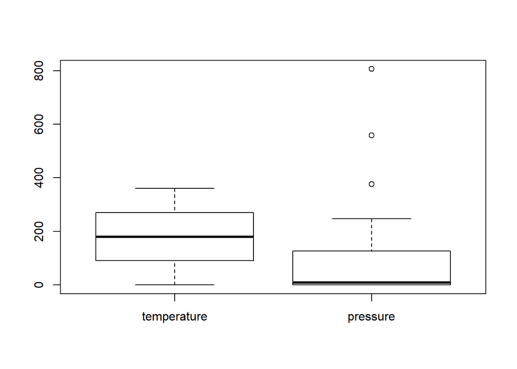

```r
boxplot(pressure)
```

### Histogram

The **histogram** of the residuals can be used to check whether the variance is normally distributed. A symmetric bell-shaped histogram which is evenly distributed around zero indicates that the normality assumption is likely to be true. A rule of thumb for the bin width is the square root of the data points, but it shouldn’t be <6.

The according function is called hist(). Put your predictors (IV’s) or the residuals? into the brackets.

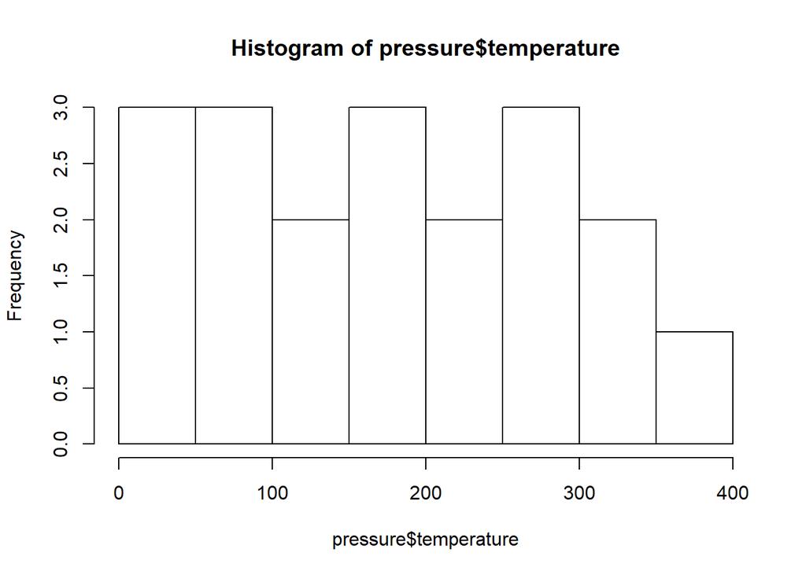

```r
hist(pressure$temperature)
```